# 14th May

Anna Hutchinson

### 1. Introduction

I now have two methods for performing functional cFDR:

1. Using interpolation (i.e. James’ method of interpolating to find L curves)
2. Using contours (i.e. defining L curves directly as the contours of the cfdr curves)

I compare the results when using these two methods. Note that the mehods only differ in the final step of defining the L curves (the cfdr/ccut values are the same).

I also include two test data points to the analysis representing p,q pairs which should give $v\approx 1$.

### 2. Results using interpolation

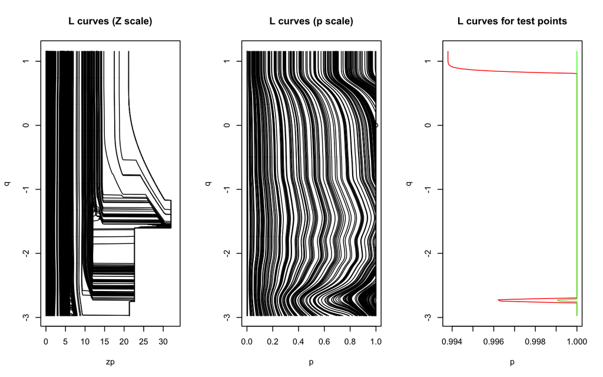

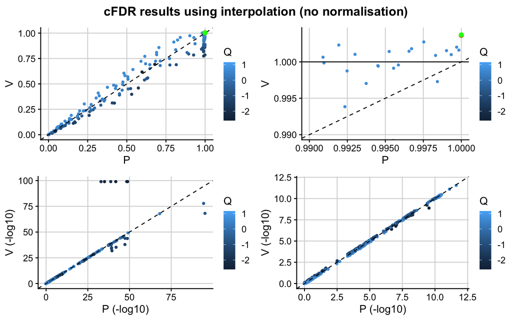

We see that when I don’t do any normalisation in the final integration step, some $v>1$. I investigate normalising the integral by the full L region (green example, defined on $[0,1] \times [lims[3], lims[4]]$) or by the L region in the red example.

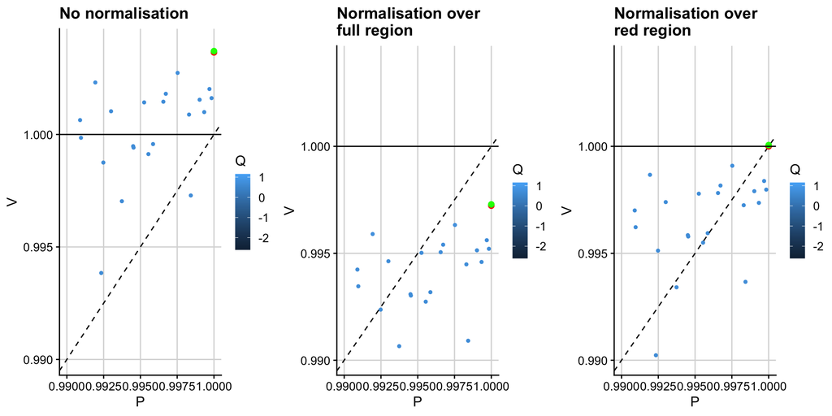

### 3. Results using contours

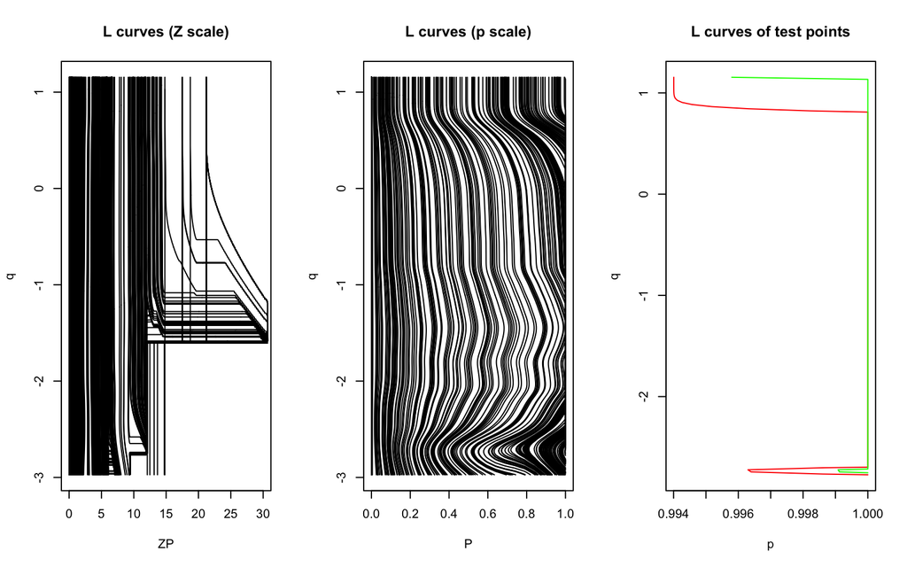

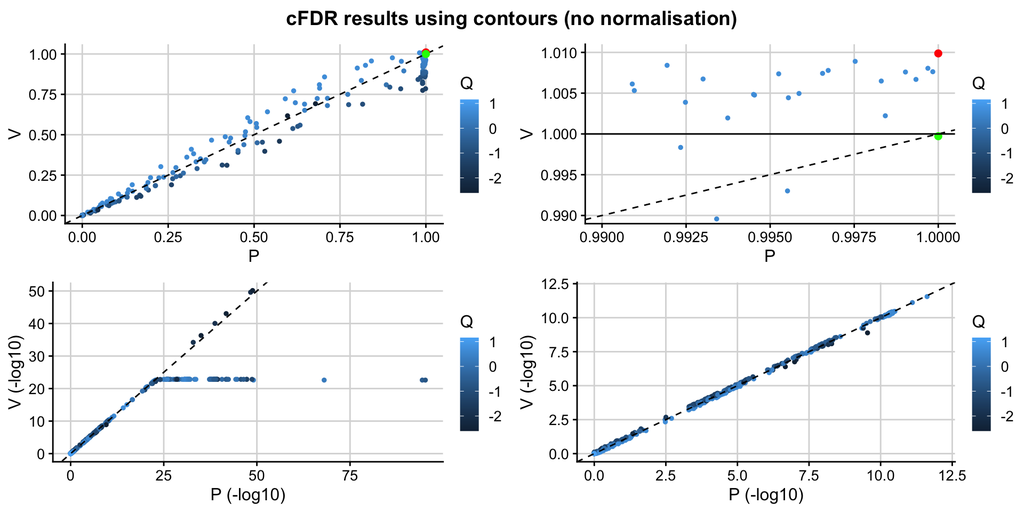

Why is the integral over the red region bigger than that over the green region????

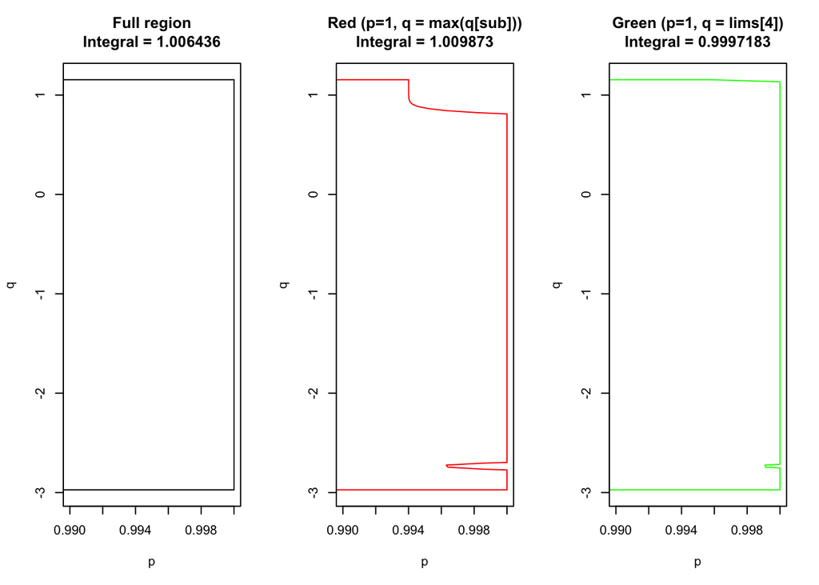

The v-values now extend even higher than 1. I investigate normalising the integral by the full L region (green example, defined on $[0,1] \times [lims[3], lims[4]]$) or by the L region in the red example.

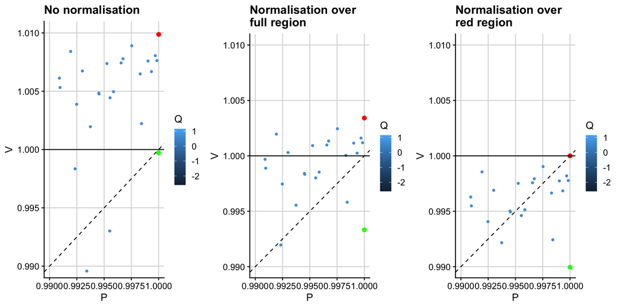

### 4. Tailing off

If we are to use the contour method then we need to fix the tailing off. I consider a single example where the interpolation method doesn’t give any tailing off but the contour method does. The tailing off is due to the extension of the L curve at $q=-2.764940271$ which is approximately `min(q[sub])` and is present in all the indices where we see tailing off. This bulge outwards increases the area of the L region therefore increasing the integral.

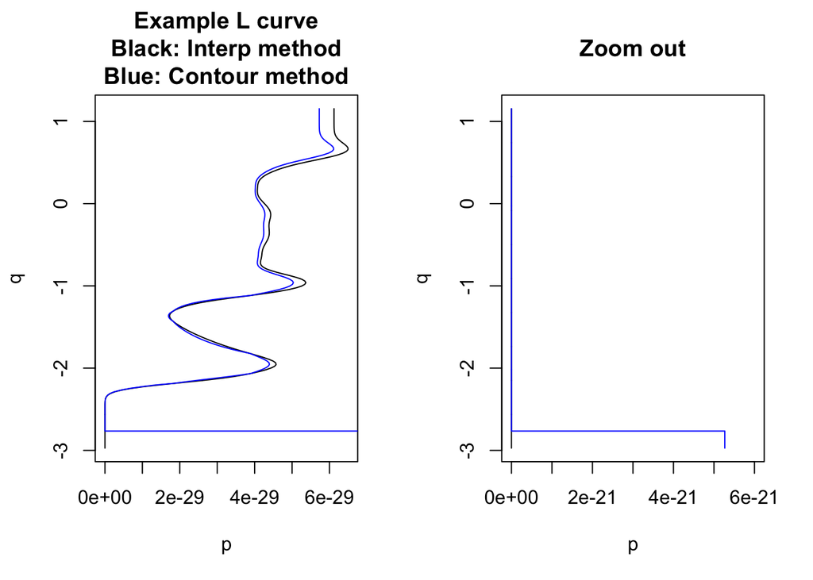

What does cgrid look like for $q<-2.764940271$? Upon visual inspection of my adjusted cfdr curves, I notice that when we zoom in there is a problem for very low q. The red lines are for $q<-2.764940271$ and this is the source of the problem.

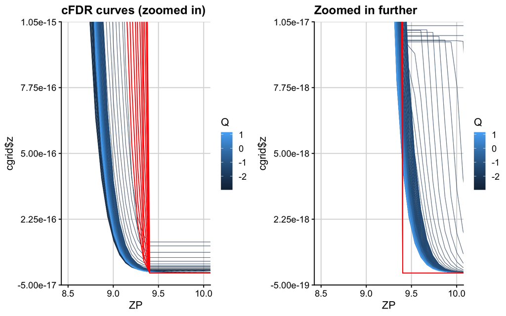

This occurs because of the following bending in the cfdr curves before I force them to be non-increasing using `cgrid$z = apply(cgrid$z,2,function(x) cummin(x-rev(cummin(rev(x)))))`.

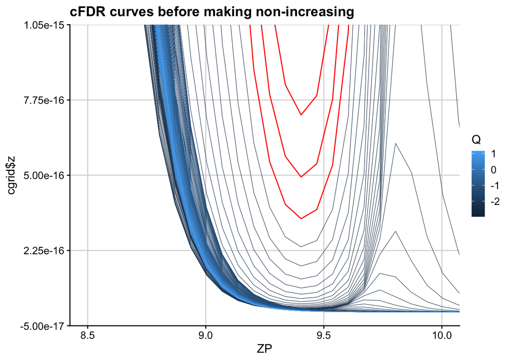

Now I need to figure out how to resolve this..

### 5. Comments

Possible problems of normalising by the red curve for the integral:

- What if `max(q[sub])` is small (reflecting more relevant annotation), is it really ok to set this $v$ value to 1?
- It seems to me that more high P values should equal 1.

#### Side note on understanding the bending which occurs even for cfdr=1 (green)

The bend occurs between `yval2[55]` and `yval2[63]`, i.e. $-2.749246<q< -2.716198$, which is exactly where the cfdr curves extend beyond 1. This means that when we read off the cfdr curves at `ccut=1`, the corresponding P value is not 1 as the cfdr curve hasnt reached 1 yet, as shown in the plot below (read up from ccut shown by the dashed line to get the x coordinate of the L curve.

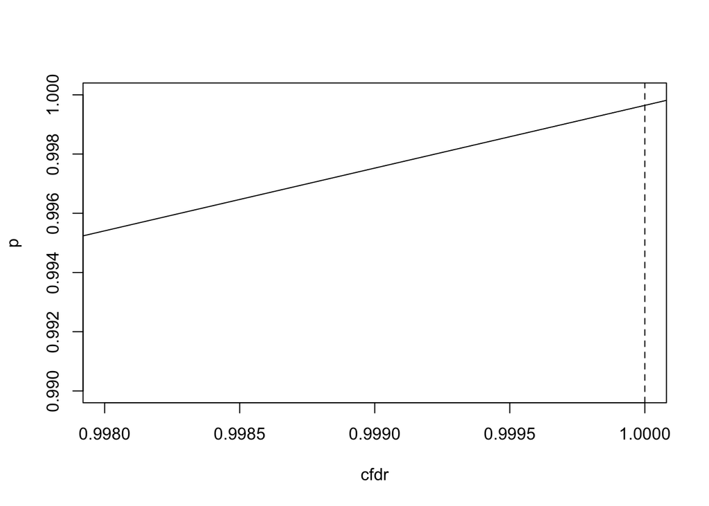

Another approach could be to prevent the cfdr curves from extending above 1. I can think of 3 possible ways to do this and show the results (using the contour method):

1. Set any $cfdr>1$ equal to 1.
2. Scale any cfdr curves that extend beyond 1 to the $[0,1]$ range (independently).
3. Scale all cfdr curves by the maximum.

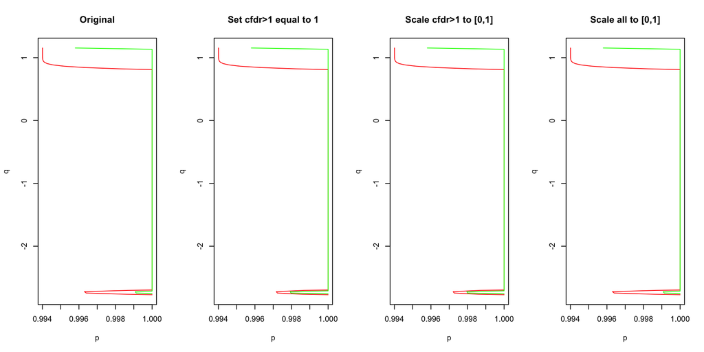

Once I have a fully working method, I will investigate further making my cfdr curves exactly in $[0,1]$.